# Stat_methods_HM1

2024-11-04

##Ex. 3.2 “Exit Poll Analysis - 2020 Arizona Senate Race”

## Problem Analysis

We’ll analyze an exit poll from the 2020 Arizona Senate race between Mark Kelly and Martha McSally.

Given information: - Sample size (n) = 1648 voters - Sample proportion for Kelly (p̂) = 0.515(51,5%) - Null hypothesis proportion (p₀) = 0.5

### (a)

Under the assumption that p₀ = 0.50 (Kelly voters)

```r
n <- 1648
p0 <- 0.5

# standard error
se <- sqrt(p0 * (1-p0) / n)
print(paste("Standard Error =", round(se, 4)))
```

```
## [1] "Standard Error = 0.0123"
```

### (b)

#### (i) Simulation

Let’s simulate 20,000 polls under the null hypothesis that p₀ = 0.50:

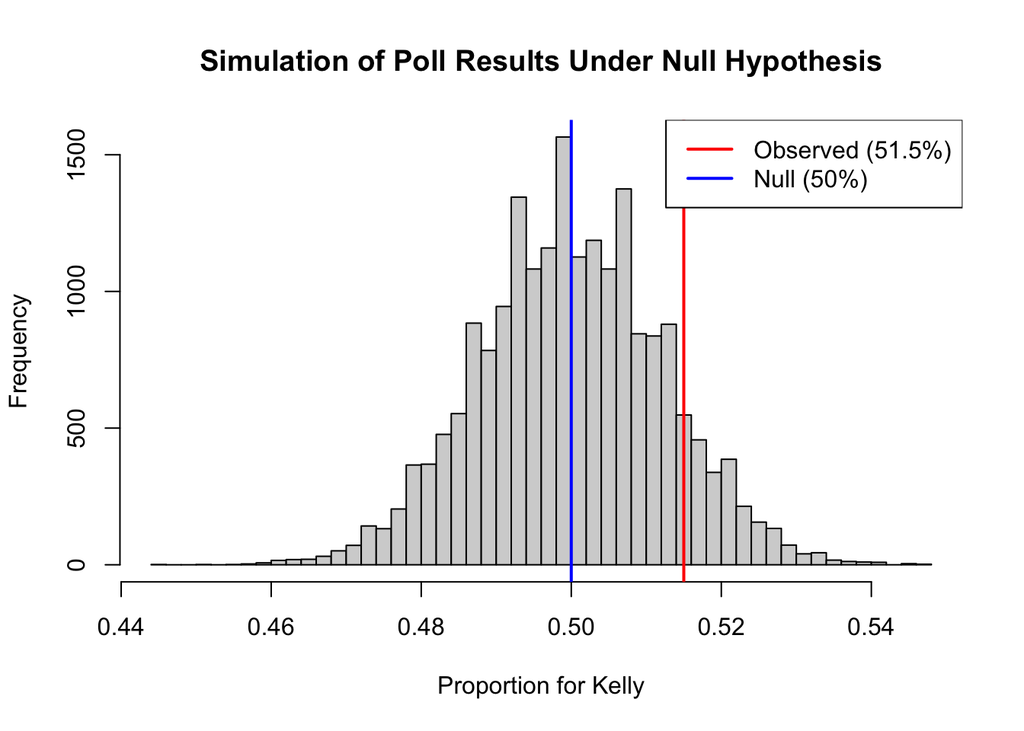

```r
# Number of simulations
n_sims <- 20000

# Simulate polls
simulated_props <- replicate(n_sims, {
  sample_results <- rbinom(1, n, p0)
  sample_results/n
})

# Calculate observed proportion
observed_prop <- 0.515

# Calculate two-sided p-value
p_value_sim <- mean(abs(simulated_props - p0) >= abs(observed_prop - p0))

# Create histogram of simulated results
hist(simulated_props,
     breaks = 50,
     main = "Simulation of Poll Results Under Null Hypothesis",
     xlab = "Proportion for Kelly",
     ylab = "Frequency")
abline(v = observed_prop, col = "red", lwd = 2)
abline(v = p0, col = "blue", lwd = 2)
legend("topright",
       legend = c("Observed (51.5%)", "Null (50%)"),
       col = c("red", "blue"),
       lwd = 2)
```

```r
print(paste("Simulated two-sided p-value =", round(p_value_sim, 4)))
```

```
## [1] "Simulated two-sided p-value = 0.225"
```

#### (ii) Using Standard Error

We can also analyze this using the standard error calculated in part (a):

```r
# Calculate z-score
z_score <- (observed_prop - p0) / se
p_value_theoretical <- 2 * (1 - pnorm(abs(z_score)))

print(paste("Z-score =", round(z_score, 4)))
```

```
## [1] "Z-score = 1.2179"
```

```r
print(paste("Theoretical two-sided p-value =", round(p_value_theoretical, 4)))
```

```
## [1] "Theoretical two-sided p-value = 0.2233"
```

### Ex. 3.16

```r
knitr::opts_chunk$set(echo = TRUE)
```

## Given Information

Population parameters: - Mean (μ) = 2.6 - Standard deviation (σ) = 1.5

Sample statistics (n = 225): - Mean (x̄) = 2.4 - Standard deviation (s) = 1.4

```r
# Population parameters
pop_mean <- 2.6
pop_sd <- 1.5

# Sample statistics
sample_size <- 225
sample_mean <- 2.4
sample_sd <- 1.4

# Calculate standard error
standard_error <- pop_sd / sqrt(sample_size)
```

## A. Population Distribution

Center: - Mean (μ) = 2.6 people per household

Spread: - Standard deviation (σ) = 1.5 people - This indicates considerable variation in household sizes - Approximately 68% of households have between 1.1 and 4.1 people (μ ± σ) - Approximately 95% of households have between -0.4 and 5.6 people (μ ± 2σ) (Since negative household sizes are impossible, the distribution is likely right-skewed)

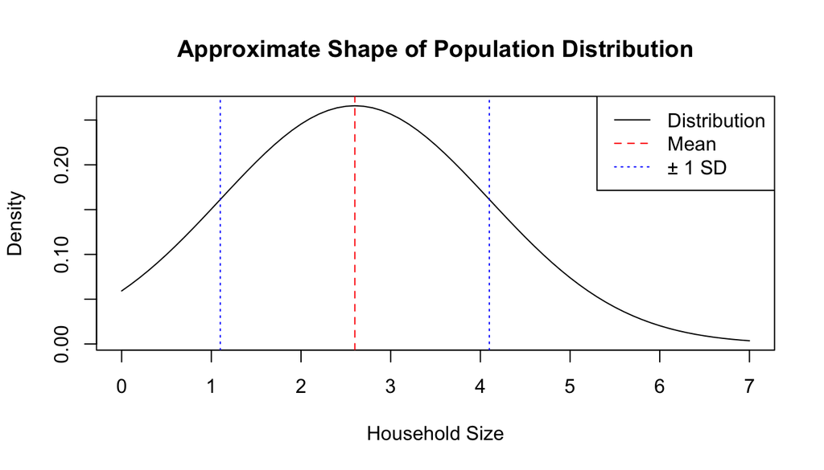

```r
x <- seq(0, 7, 0.1)
y <- dnorm(x, mean = pop_mean, sd = pop_sd)
plot(x, y, type = "l",
     main = "Approximate Shape of Population Distribution",
     xlab = "Household Size",
     ylab = "Density")
abline(v = pop_mean, col = "red", lty = 2)
abline(v = c(pop_mean - pop_sd, pop_mean + pop_sd), col = "blue", lty = 3)
legend("topright",
       legend = c("Distribution", "Mean", "± 1 SD"),
       col = c("black", "red", "blue"),
       lty = c(1, 2, 3))
```

## B. Sample Data Distribution

225

Center: - Sample mean (x̄) = 2.4 people per household - Slightly lower than the population mean (2.6)

Spread: - Sample standard deviation (s) = 1.4 people - Slightly less variable than the population - Approximately 68% of sampled households have between 1.0 and 3.8 people - Approximately 95% of sampled households have between -0.4 and 5.2 people

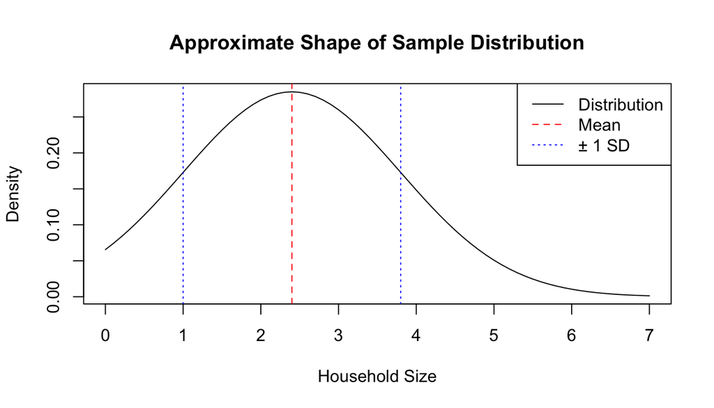

```r
x <- seq(0, 7, 0.1)
y <- dnorm(x, mean = sample_mean, sd = sample_sd)
plot(x, y, type = "l",
     main = "Approximate Shape of Sample Distribution",
     xlab = "Household Size",
     ylab = "Density")
abline(v = sample_mean, col = "red", lty = 2)
abline(v = c(sample_mean - sample_sd, sample_mean + sample_sd), col = "blue", lty = 3)
legend("topright",
       legend = c("Distribution", "Mean", "± 1 SD"),
       col = c("black", "red", "blue"),
       lty = c(1, 2, 3))
```

## C. Sampling Distribution of the Sample Mean for 225 homes

The sampling distribution describes how sample means would vary if we repeatedly took samples of 225 homes.

Center: - Mean of all possible sample means (μx̄) = 2.6 (Equal to the population mean)

Spread: - Standard error = 0.1 people (σ/√n = 1.5/√225) - Much less variable than individual observations - Approximately 68% of sample means would fall between 2.5 and 2.7 people (68% interval: 2.6 ± 0.1 = (2.5, 2.7)) - Approximately 95% of sample means would fall between 2.4 and 2.8 people (95% interval: 2.6 ± (2 × 0.1) = (2.4, 2.8))

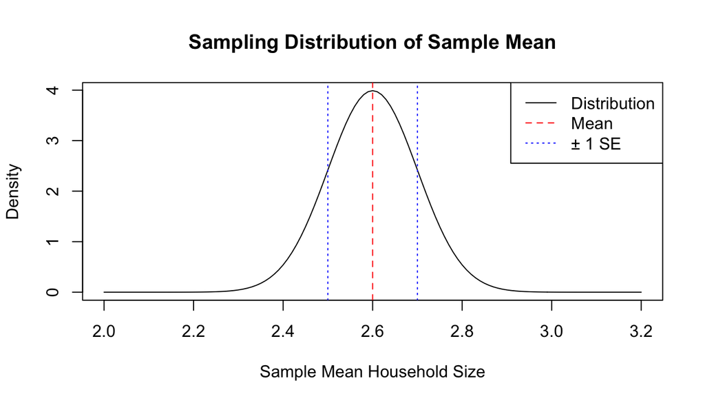

```r
x <- seq(2, 3.2, 0.01)
y <- dnorm(x, mean = pop_mean, sd = standard_error)
plot(x, y, type = "l",
     main = "Sampling Distribution of Sample Mean",
     xlab = "Sample Mean Household Size",
     ylab = "Density")
abline(v = pop_mean, col = "red", lty = 2)
abline(v = c(pop_mean - standard_error, pop_mean + standard_error), col = "blue", lty = 3)
legend("topright",
       legend = c("Distribution", "Mean", "± 1 SE"),
       col = c("black", "red", "blue"),
       lty = c(1, 2, 3))
```

### Terzo esercizio (3.24)

```r
knitr::opts_chunk$set(echo = TRUE)
set.seed(123)
```

## Possiblee Pop. Distribution

Distribution for the number of alcoholic drinks consumed in the past day (Y) right-skewed distribution since: - Many people don’t drink (0 drinks) - Some people have a few drinks - A smaller number of people have many drinks - Negative values are impossible

```r
# Create population distribution parameters
n_population <- 100000  # Large population size

prob_zero <- 0.4  # 40% of people don't drink

shape <- 1.5
rate <- 1

# Generate population data
zeros <- rep(0, prob_zero * n_population)
drinkers <- rgamma(n = (1 - prob_zero) * n_population, shape = shape, rate = rate)
population <- c(zeros, drinkers)

# Calculate population parameters (mean and standard dev)
pop_mean <- mean(population)
pop_sd <- sd(population)

# Print population parameters
print(paste("Population Mean:", round(pop_mean, 3)))
```

```
## [1] "Population Mean: 0.9"
```

```r
print(paste("Population SD:", round(pop_sd, 3)))
```

```
## [1] "Population SD: 1.199"
```

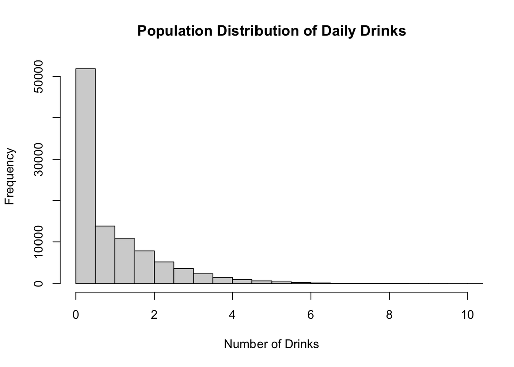

```r
# Visualize population distribution
hist(population,
     breaks = 50,
     main = "Population Distribution of Daily Drinks",
     xlab = "Number of Drinks",
     ylab = "Frequency",
     xlim = c(0, 10))
```

## A. Single Sample Analysis

Let’s draw one random sample of size 1000 from this population:

```r
# single sample
sample_size <- 1000
single_sample <- sample(population, size = sample_size, replace = TRUE)

# sample statistics
sample_mean <- mean(single_sample)
sample_sd <- sd(single_sample)

# comparisons
print("Sample vs Population Statistics:")
```

```
## [1] "Sample vs Population Statistics:"
```

```r
print(paste("Sample Mean:", round(sample_mean, 3), "vs Population Mean:", round(pop_mean, 3)))
```

```
## [1] "Sample Mean: 0.84 vs Population Mean: 0.9"
```

```r
print(paste("Sample SD:", round(sample_sd, 3), "vs Population SD:", round(pop_sd, 3)))
```

```
## [1] "Sample SD: 1.12 vs Population SD: 1.199"
```

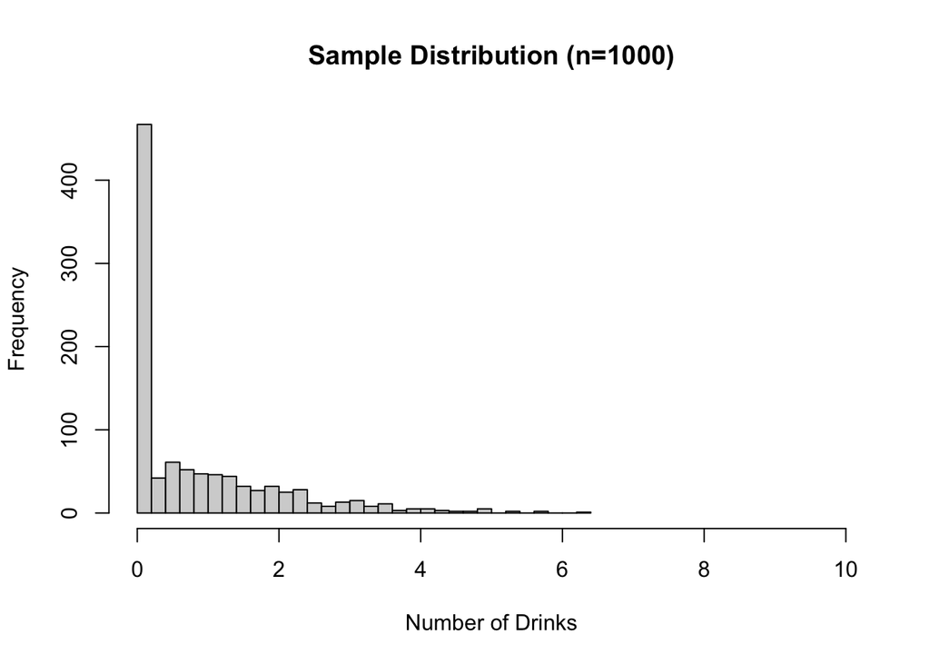

```r
# Visualize sample distribution
hist(single_sample,
     breaks = 30,
     main = "Sample Distribution (n=1000)",
     xlab = "Number of Drinks",
     ylab = "Frequency",
     xlim = c(0, 10))
```

## B. Sampling Distribution Analysis

simulate 10,000 samples of size 1000 each to approximate the sampling distribution:

```r
# Simulate 10000 samples
n_simulations <- 10000
sample_means <- numeric(n_simulations)

for(i in 1:n_simulations) {
    sample_means[i] <- mean(sample(population, size = sample_size, replace = TRUE))
}

# sampling distribution statistics
sampling_mean <- mean(sample_means)
sampling_sd <- sd(sample_means)

# theoretical standard error
theoretical_se <- pop_sd/sqrt(sample_size)

# Print results
print("Sampling Distribution Statistics:")
```

```
## [1] "Sampling Distribution Statistics:"
```

```r
print(paste("Simulated Mean of Sample Means:", round(sampling_mean, 4)))
```

```
## [1] "Simulated Mean of Sample Means: 0.8999"
```

```r
print(paste("Theoretical Mean (Population Mean):", round(pop_mean, 4)))
```

```
## [1] "Theoretical Mean (Population Mean): 0.9001"
```

```r
print(paste("Simulated Standard Error:", round(sampling_sd, 4)))
```

```
## [1] "Simulated Standard Error: 0.0382"
```

```r
print(paste("Theoretical Standard Error:", round(theoretical_se, 4)))
```

```
## [1] "Theoretical Standard Error: 0.0379"
```

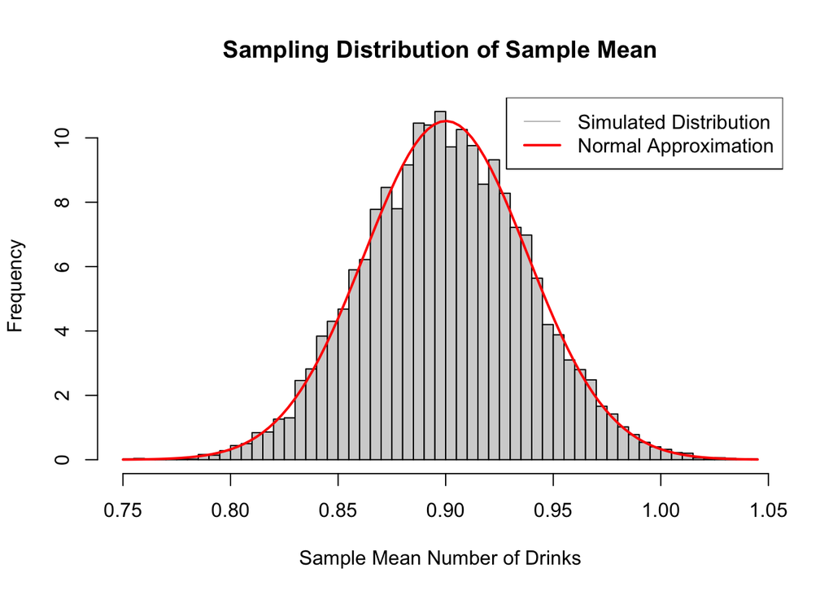

```r
# Visualize sampling distribution
hist(sample_means,
     breaks = 50,
     main = "Sampling Distribution of Sample Mean",
     xlab = "Sample Mean Number of Drinks",
     ylab = "Frequency",
     probability = TRUE)
curve(dnorm(x, mean = pop_mean, sd = theoretical_se),
      add = TRUE,
      col = "red",
      lwd = 2)
legend("topright",
       legend = c("Simulated Distribution", "Normal Approximation"),
       col = c("grey", "red"),
       lwd = c(1, 2))
```

## Key Observations

1. Population Distribution:
   - Right-skewed distribution
   - 40% of people have 0 drinks
   - Mean and standard deviation
   - Represents the true distribution of daily drinks in the population
2. Single Sample (n = 1000):
   - Shows similar shape to population
   - Sample mean and standard deviation are close to population values
   - Demonstrates what we might see in a real survey (real data)
3. Sampling Distribution:
   - Nearly normal in shape (Central Limit Theorem)
   - Centered very close to the population mean
   - Standard error (SD of sampling distribution) is close to theoretical value
   - Represents the distribution of sample means if we repeated the survey many times
   - Much narrower than the population distribution, showing that sample means vary less than individual observations
4. Theory vs Simulation:
   - Simulated results closely match theoretical expectations
   - Small differences due to random variation in simulation
   - Confirms the accuracy of our theoretical understanding of sampling distributions

so we can demostrat that the sampling distribution of the mean becomes approximately normal (due to the CLT) even though the underlying population distribution is highly skewed.